# Genome-Wide Association Studies

# What is a Genome-Wide Association Study?

## Background Information

The human genome is very fascinating! The genome consists of all of a person’s DNA, and scientists have been studying it for many years. Across all humans, our DNA is very similar, but there are certain regions on the genome that are known to differ from person to person. These regions are called **genetic variants** and they are useful in studying what makes us genetically different from one another. There are multiple types of genetic variants, but Genome-Wide Association Studies use **Single Nucleotide Variants**, or SNVs, which are single nucleotide changes in the DNA sequence. These genetic variants can give scientists insights into a person’s inherited traits, diseases, and ancestry.  
**Genome-Wide Association Studies**, or GWAS are used find genetic variants that are significantly associated with the trait of interest by testing thousands of genetic variants across the entire genome. To test a genetic variant, scientists look at **Single Nucleotide Polymorphisms**, or SNPs, on the genomes of *cases* (people expressing the trait of interest) and *controls* (people without the trait of interest) to declare if the nucleotides at that SNP position are associated with possession of the trait of interest. SNPs differ from SNVs because they represent a variation that is present in at least 1% of the population.  
Once scientists have identified genetic variants that **are** associated with a particular trait of interest, they can observe this genetic variant in new subjects to determine if the subject may have inherited the genes for the trait of interest. This practice can be **life saving** when used in medical contexts because it can provide individuals with a proactive approach to their health before an official diagnosis and ensure that individuals can prepare for the treatment they need.  
The supplementary article [Genome-Wide Association Study of 14,000 Cases of Seven Common Diseases and 3,000 Shared Controls (Nature)](https://www.nature.com/articles/nature05911) was an innovative paper that defined common protocols for implementing GWAS for scientific studies. This paper is a foundation of the GWAS and was made possible by developments in DNA sequencing, allowing the analysis of 500,000 SNPs across the entire genome of each individual.

# Implementing a Genome-Wide Association Study

## Big Data (p > n)

As mentioned in the introduction, genetic data is **BIG** data. Since there are more variables than data points in the data set, it is not possible to use multiple linear regression to analyze association of genetic variants and traits of interest. There is a lot of math that can explain why multiple linear regression doesn’t work, but for the sake of this content summary, you are spared from that.

## Marginal Regression

Since we are unable to use multiple linear regression on all the data points, we can use a marginal regression that looks at each SNV one at a time. The code will walk you through how to run this marginal regression on 165 individuals. Enjoy!

### Set Up

```r
library(snpStats)
library(tidyverse)
library(broom)
library(qqman)
```

The genetic data that we will use for this tutorial contain real genotype information and a simulated binary phenotype for 165 individuals of European ancestry from the [International HapMap Project (“HapMap”)](https://www.genome.gov/10001688/international-hapmap-project). This data was used to write a [tutorial](https://github.com/MareesAT/GWA_tutorial/) on how to conduct a genome-wide association study by researchers in the Netherlands and France.  
This zip file contains three files `HapMap_3_r3_1.bed`, `HapMap_3_r3_1.bim`, and `HapMap_3_r3_1.fam` that store genetic data. `HapMap_3_r3_1.bed` stores genotypes for individuals in this study, `HapMap_3_r3_1.bim` stores SNP information, and `HapMap_3_r3_1.fam` file contains other information about the individuals in the study.

```r
bed <- 'DataFiles/1_QC_GWAS/HapMap_3_r3_1.bed'
bim <- 'DataFiles/1_QC_GWAS/HapMap_3_r3_1.bim'
fam <- 'DataFiles/1_QC_GWAS/HapMap_3_r3_1.fam'
```

```r
# NOTE: this might take a minute or two
hapmap <- read.plink(bed, bim, fam)
```

Now, the hapmap data object contains the three data files as described above.

### Minor Allele Frequency Analysis

First, we will begin by assessing minor allele frequency for each SNP.

Add the MAF to the hapmap data oject.

```r
maf <- col.summary(hapmap$genotypes)$MAF
# add new MAF variable
hapmap$map <- hapmap$map %>%
  mutate(MAF = maf)

# look at SNP info again
head(hapmap$map)
```

```
           chromosome   snp.name cM position allele.1 allele.2        MAF
rs2185539           1  rs2185539 NA   556738        T        C 0.00000000
rs11510103          1 rs11510103 NA   557616        G        A 0.00621118
rs11240767          1 rs11240767 NA   718814        T        C 0.00000000
rs3131972           1  rs3131972 NA   742584        A        G 0.15757576
rs3131969           1  rs3131969 NA   744045        A        G 0.13030303
rs1048488           1  rs1048488 NA   750775        C        T 0.15853659
```

Do you notice that both the first and third SNPs in this data set have a MAF equal to 0? This means that in these SNPs, **all** individuals are homozygous for the major allele. Since the minor allele is not present at all in the study population, this is not an effective SNP because all individuals possess the same allele.

### Reformat Data for Analysis

The `snpStats` package uses a unique format to store data. Currently, genotypes are coded as 01, 02, and 03 (with 00 representing missing values).

```r
# look at first five rows/columns
hapmap$genotypes@.Data[1:5,1:5]
```

```
        rs2185539 rs11510103 rs11240767 rs3131972 rs3131969
NA06989        03         03         03        02        02
NA11891        03         03         03        02        03
NA11843        03         03         03        03        03
NA12341        03         03         03        02        02
NA12739        03         03         03        03        03
```

The packages that we use for analysis require us to reformat this into 0’s, 1’s, 2’s, and NA’s.

```r
# what type of object is hapmap$genotypes
class(hapmap$genotypes)
```

```
[1] "SnpMatrix"
attr(,"package")
[1] "snpStats"
```

```r
# convert from "SnpMatrix" to "numeric"
X <- as(hapmap$genotypes, "numeric")

# what type of object do we have now
class(X)
```

```
[1] "matrix" "array"
```

```r
# look at first five rows/columns to confirm conversion looks ok
X[1:5, 1:5]
```

```
        rs2185539 rs11510103 rs11240767 rs3131972 rs3131969
NA06989         2          2          2         1         1
NA11891         2          2          2         1         2
NA11843         2          2          2         2         2
NA12341         2          2          2         1         1
NA12739         2          2          2         2         2
```

Now, your data is reformatted and ready for more analysis!

### Trait Simulation

In research, it is very common for scientists to analyze **experimental** data because it gives scientists the power of analyzing a changing independent variable. In genetics, however, genetic data is collected from **observational** studies that do not have the same changing independent variable (because implementing disease inheritance to babies would not be ethical).

Instead of only relying on observational data, scientists often use **simulations** to gain power in interpretation of genetic data. Simulations are a very helpful tool because it gives scientists the power to control the data by assigning controls and cases. The idea behind simulations is that scientists can assign *cases* to observations that would typically be considered *controls* and test them by performing statistical methods. If the *false* cases are being identified as *true* and *significant* by the statistical method, then the scientist can exclude this method from further analysis because it is not producing accurate results.  
In our data set, the genotype data is *real*, but the phenotype data is *simulated*.  
To show you how to simulate these phenotypic traits, we will show an example of a trait that depends on the SNP known as *rs2476601*.  
Research has identified this SNP as a genetic variant that is strongly associated with autoimmune diseases like type 1 diabetes, rheumatoid arthritis and systemic lupus erythematosus. Its minor allele is associated with autoimmunity and alters immune cell composition and function.

```r
hapmap$map %>%
  filter(snp.name == 'rs2476601')
```

```
          chromosome  snp.name cM  position allele.1 allele.2       MAF
rs2476601          1 rs2476601 NA 114179091        A        G 0.1196319
```

Now, we will create a quantitative trait `y` that depends on the genotype at this SNP plus some random noise. It is important to include random noise in this simulation because real genetic data is imperfect, there are mutations that alter the DNA sequence. For this example, we will assign this SNP an “effect size” of 2: for every additional copy of the minor allele that an individual carries, their trait value will increase by 2 units (plus or minus some random noise).

```r
# simulate trait
set.seed(494) # set seed for reproducibility
n <- nrow(X) # calculate the number of individuals
y <- 2 * X[,'rs2476601'] + rnorm(n, 0, 1) # y = 2 * x + e

# look at the first few simulated trait values
head(y)
```

```
  NA06989   NA11891   NA11843   NA12341   NA12739   NA10850
0.2082684 3.6267809 3.3422648 1.1696396 3.9450827 4.8350451
```

We have designed this simulation so that the trait `y` depends on the causal SNP, rs2476601, and nothing else. We can use this truth to assess the performance of our statistical methods in the Genome-Wide Association Study.

### Genome-Wide Association Study

First, we need to clean the data to remove the ineffective monomorphic SNPs:

```r
# keep only those SNPs with MAF > 0
map.clean <- hapmap$map %>%
  filter(MAF > 0)
```

Now, we need to remove these monomorphic SNPs from our genotype matrix (`X`).

```r
# create vector of which SNPs have a MAF of 0
monomorphic <- which(maf == 0)
head(monomorphic)
```

```
[1]  1  3 10 11 12 17
```

```r
# remove columns in the monomorphic vector
X.clean <- X[,-monomorphic]
```

Check to make sure that you removed the correct amount of SNPs from the data:

```r
dim(X.clean)
```

```
[1]     165 1283751
```

For the purpose of this content summary, we will complete the same procedure as a GWAS, but limit the SNPs to only those that exist on the first chromosome to reduce computing time.

```r
chr1.snps <- which(map.clean$chromosome == 1)
head(chr1.snps)
```

```
[1] 1 2 3 4 5 6
```

```r
length(chr1.snps)
```

```
[1] 103646
```

To analyze all the SNPs on chromosome 1, we can write a loop to fit a linear regression model at each SNP. For each SNP model, we’ll record the estimates (`betas`), standard errors (`ses`), test statistics (`tstats`) and p-values (`pvals`) for the coefficient of interest (the slope).

```r
# NOTE: this will take awhile to run and render
#| cache: true
# set up empty vectors for storing results
betas <- c()
ses <- c()
tstats <- c()
pvals <- c()

# loop through chromosome 1 SNPs
for(i in chr1.snps){
  # print out occasional updates telling us what SNP we're analyzing
  if(i %% 10000 == 0) print(paste('Analyzing SNP', i))
  # fit model
  mod <- lm(y ~ X.clean[,i])
  # get coefficient information
  coefinfo <- tidy(mod)
  # record estimate, SE, test stat, and p-value
  betas[i] <- coefinfo$estimate[2]
  ses[i] <- coefinfo$std.error[2]
  tstats[i] <- coefinfo$statistic[2]
  pvals[i] <- coefinfo$p.value[2]
}
```

```
[1] "Analyzing SNP 10000"
[1] "Analyzing SNP 20000"
[1] "Analyzing SNP 30000"
[1] "Analyzing SNP 40000"
[1] "Analyzing SNP 50000"
[1] "Analyzing SNP 60000"
[1] "Analyzing SNP 70000"
[1] "Analyzing SNP 80000"
[1] "Analyzing SNP 90000"
[1] "Analyzing SNP 100000"
```

Now, we need to add the results of this marginal regression to our map data frame that contains information about each SNP.

```r
# start with the map info for the chr 1 SNPs
chr1.results <- map.clean %>%
  filter(chromosome == 1)

# then add betas, SEs, etc.
chr1.results <- chr1.results %>%
  mutate(Estimate = betas,
         Std.Error = ses,
         Test.Statistic = tstats,
         P.Value = pvals)

# look at results
head(chr1.results)
```

```
           chromosome   snp.name cM position allele.1 allele.2        MAF
rs11510103          1 rs11510103 NA   557616        G        A 0.00621118
rs3131972           1  rs3131972 NA   742584        A        G 0.15757576
rs3131969           1  rs3131969 NA   744045        A        G 0.13030303
rs1048488           1  rs1048488 NA   750775        C        T 0.15853659
rs12562034          1 rs12562034 NA   758311        A        G 0.10909091
rs12124819          1 rs12124819 NA   766409        G        A 0.28658537
              Estimate Std.Error Test.Statistic    P.Value
rs11510103 -0.13716883 0.6359358     -0.2156960 0.82950466
rs3131972  -0.38450101 0.1969700     -1.9520787 0.05266367
rs3131969  -0.14108060 0.2086905     -0.6760278 0.49999293
rs1048488  -0.37371908 0.1970853     -1.8962297 0.05973218
rs12562034  0.06013127 0.2215724      0.2713843 0.78644313
rs12124819 -0.22912006 0.1498249     -1.5292522 0.12817656
```

Finally, we can create a Manhattan Plot which shows the SNPs that are significantly associated with the trait of interest. Manhattan plots are very common in statistical genetics and are created by negative log-transforming the y-axis to highlight p-values that are significant. Manhattan plots represent the significant p-values higher on the y-axis, making them easier to read, yet counter-intuitive since the more significant a p-value is, the closer it is to zero.

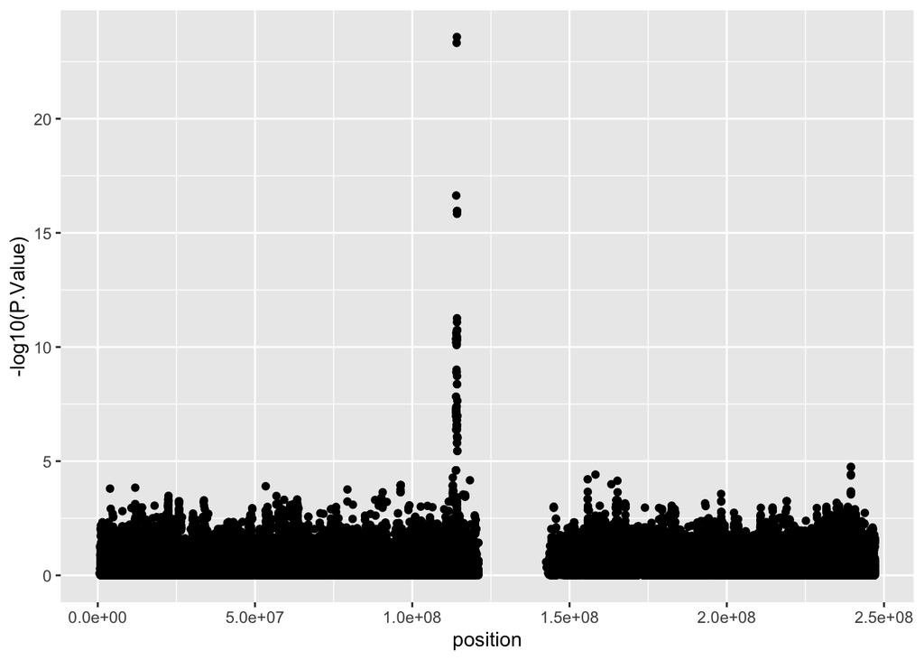

```r
# your code here
chr1.results %>%
  ggplot() +
  geom_point(aes(x = position, y = -log10(P.Value)))
```

### Conclusion

You now have the understanding and skills to implement a Genome-Wide Association Study and plot your findings! In order to implement this on all chromosomes, follow the same code, but do not filter to only select SNPs on chromosome 1. This will allow you to loop through all the SNPs on all the chromosomes and may take up to 30 minutes to run!